# R Notebook

**Principles of Data Visualization and Introduction to ggplot2**

I have provided you with data about the 5,000 fastest growing companies in the US, as compiled by Inc. magazine. lets read this in:

```r
inc <- read.csv("https://raw.githubusercontent.com/charleyferrari/CUNY_DATA_608/master/module1/Data/inc5000_data.csv", header= TRUE)
```

And lets preview this data:

```r
head(inc)
```

```
##   Rank                         Name Growth_Rate   Revenue
## 1    1                         Fuhu      421.48 1.179e+08
## 2    2        FederalConference.com      248.31 4.960e+07
## 3    3                The HCI Group      245.45 2.550e+07
## 4    4                      Bridger      233.08 1.900e+09
## 5    5                       DataXu      213.37 8.700e+07
## 6    6 MileStone Community Builders      179.38 4.570e+07
##                       Industry Employees         City State
## 1 Consumer Products & Services       104   El Segundo    CA
## 2          Government Services        51     Dumfries    VA
## 3                       Health       132 Jacksonville    FL
## 4                       Energy        50      Addison    TX
## 5      Advertising & Marketing       220       Boston    MA
## 6                  Real Estate        63       Austin    TX
```

```r
summary(inc)
```

```
##       Rank          Name            Growth_Rate         Revenue
##  Min.   :   1   Length:5001        Min.   :  0.340   Min.   :2.000e+06
##  1st Qu.:1252   Class :character   1st Qu.:  0.770   1st Qu.:5.100e+06
##  Median :2502   Mode  :character   Median :  1.420   Median :1.090e+07
##  Mean   :2502                      Mean   :  4.612   Mean   :4.822e+07
##  3rd Qu.:3751                      3rd Qu.:  3.290   3rd Qu.:2.860e+07
##  Max.   :5000                      Max.   :421.480   Max.   :1.010e+10
##
##    Industry           Employees           City              State
##  Length:5001        Min.   :    1.0   Length:5001        Length:5001
##  Class :character   1st Qu.:   25.0   Class :character   Class :character
##  Mode  :character   Median :   53.0   Mode  :character   Mode  :character
##                     Mean   :  232.7
##                     3rd Qu.:  132.0
##                     Max.   :66803.0
##                     NA's   :12
```

Think a bit on what these summaries mean. Use the space below to add some more relevant non-visual exploratory information you think helps you understand this data

Looks to me like there are possibly outliers in the growth rate, employees and the revenue. Let’s take a look at those

```r
out <- boxplot.stats(inc$Growth_Rate)$out
out_ind <- which(inc$Growth_Rate %in% c(out))
inc[out_ind, ]
```

```
##      Rank                                     Name Growth_Rate   Revenue
## 1       1                                     Fuhu      421.48 1.179e+08
## 2       2                    FederalConference.com      248.31 4.960e+07
## 3       3                            The HCI Group      245.45 2.550e+07
## 4       4                                  Bridger      233.08 1.900e+09
## 5       5                                   DataXu      213.37 8.700e+07
## 6       6             MileStone Community Builders      179.38 4.570e+07
## 7       7                    Value Payment Systems      174.04 2.550e+07
## 8       8                     Emerge Digital Group      170.64 2.390e+07
## 9       9                                Goal Zero      169.81 3.310e+07
## 10     10                                 Yagoozon      166.89 1.860e+07
## 11     11                                   OBXtek      164.33 2.960e+07
## 12     12                                   AdRoll      150.65 3.410e+07
## 13     13                               uBreakiFix      141.02 1.700e+07
## 14     14                                    Sparc      128.63 2.110e+07
```

[output cut: 1285 more lines]

```r
out <- boxplot.stats(inc$Employees)$out
out_ind <- which(inc$Employees %in% c(out))
inc[out_ind, ]
```

```
##      Rank                                        Name Growth_Rate   Revenue
## 15     15                                LivingSocial      123.33 5.360e+08
## 23     23                 Wingspan Portfolio Advisors       87.69 7.700e+07
## 28     28                                        Kony       77.86 5.110e+07
## 39     39                         Intellect Resources       65.54 3.000e+07
## 45     45                      Silver Spring Networks       58.67 1.967e+08
## 64     64                               GSC Packaging       48.13 1.126e+08
## 84     84                            Next Step Living       38.90 2.940e+07
## 94     94                                Alex and Ani       35.69 7.980e+07
## 97     97                          Discovery Services       35.08 1.660e+07
## 136   136                                   Videology       27.27 1.375e+08
## 142   142                               Cloud Sherpas       26.33 7.530e+07
## 164   164                         BrightSource Energy       24.15 2.911e+08
## 180   180             Sky Zone Indoor Trampoline Park       22.49 5.060e+07
## 194   194                            Target Logistics       21.31 1.219e+08
```

[output cut: 1207 more lines]

```r
out <- boxplot.stats(inc$Revenue)$out
out_ind <- which(inc$Revenue %in% c(out))
inc[out_ind, ]
```

```
##      Rank                                       Name Growth_Rate   Revenue
## 1       1                                       Fuhu      421.48 1.179e+08
## 4       4                                    Bridger      233.08 1.900e+09
## 5       5                                     DataXu      213.37 8.700e+07
## 15     15                               LivingSocial      123.33 5.360e+08
## 17     17                          Intelligent Audit      105.73 1.450e+08
## 23     23                Wingspan Portfolio Advisors       87.69 7.700e+07
## 45     45                     Silver Spring Networks       58.67 1.967e+08
## 64     64                              GSC Packaging       48.13 1.126e+08
## 72     72                                Rocket Fuel       44.51 1.066e+08
## 73     73                                      iSend       44.41 1.058e+08
## 75     75                 Equinox Business Solutions       42.35 8.260e+07
## 93     93                                Build Group       35.91 1.015e+08
## 94     94                               Alex and Ani       35.69 7.980e+07
## 98     98                                        VRx       34.79 7.240e+07
```

[output cut: 1183 more lines]

```r
summary(as.factor(inc[['Industry']]))
```

```
##      Advertising & Marketing Business Products & Services
##                          471                          482
##            Computer Hardware                 Construction
##                           44                          187
## Consumer Products & Services                    Education
##                          203                           83
##                       Energy                  Engineering
##                          109                           74
##       Environmental Services           Financial Services
##                           51                          260
##              Food & Beverage          Government Services
##                          131                          202
##                       Health              Human Resources
##                          355                          196
##                    Insurance                  IT Services
##                           50                          733
##   Logistics & Transportation                Manufacturing
##                          155                          256
##                        Media                  Real Estate
##                           54                           96
##                       Retail                     Security
##                          203                           73
##                     Software           Telecommunications
##                          342                          129
##         Travel & Hospitality
##                           62
```

Looks like there are 25 industries, ranging from 44 to 733 entries. With IT being by far the most common.

```r
#This is a function to summarize categories
get_cat_data = function(target,col,replace_na=NA) {

   col = replace(col,is.na(col),replace_na)
   summ = aggregate(target, list(col), FUN=function(x) c(length(x),mean(x),median(x)))
   summ[['Group.1']] = as.character(summ[['Group.1']])
   summ = as.data.frame(cbind(summ$Group.1,summ$x[,1],summ$x[,2],summ$x[,3]))
   colnames(summ) = c('value','count','mean','median')
   summ['count'] = as.numeric(summ[['count']])
   summ['mean'] = as.numeric(summ[['mean']])
   summ['median'] = as.numeric(summ[['median']])

   summ = summ[summ['count']>10,]
   summ = summ[order(-summ['mean']),]
   return(summ)
}

summ = get_cat_data(inc$Growth_Rate,inc$Industry)
summ
```

```
##                           value count     mean median
## 7                        Energy   109 9.603303  2.080
## 5  Consumer Products & Services   203 8.776108  1.820
## 20                  Real Estate    96 7.746667  2.070
## 12          Government Services   202 7.238168  2.110
## 1       Advertising & Marketing   471 6.225478  1.610
## 21                       Retail   203 6.184729  1.760
## 10           Financial Services   260 5.435308  1.485
## 23                     Software   342 5.020643  1.715
## 13                       Health   355 4.856394  1.570
## 19                        Media    54 4.374074  1.940
## 17   Logistics & Transportation   155 4.339226  1.320
## 3             Computer Hardware    44 4.089773  1.045
## 6                     Education    83 3.642651  1.200
## 11              Food & Beverage   131 3.636565  1.320
## 2  Business Products & Services   482 3.518485  1.095
## 22                     Security    73 3.388904  1.540
## 4                  Construction   187 3.366684  1.300
## 16                  IT Services   733 3.331814  1.380
## 14              Human Resources   196 3.300459  1.520
## 24           Telecommunications   129 2.883721  1.280
## 25         Travel & Hospitality    62 2.353065  1.135
## 18                Manufacturing   256 2.295391  1.070
## 9        Environmental Services    51 2.068039  1.410
## 15                    Insurance    50 2.008400  1.200
## 8                   Engineering    74 1.984324  1.350
```

You can see the mean is very high for some of these, but the median is more reasonable. Again, I don’t think the distributions here are well represented by a normal distribution and so it’s hard to get much out of these.

## Question 1

Create a graph that shows the distribution of companies in the dataset by State (ie how many are in each state). There are a lot of States, so consider which axis you should use. This visualization is ultimately going to be consumed on a ‘portrait’ oriented screen (ie taller than wide), which should further guide your layout choices.

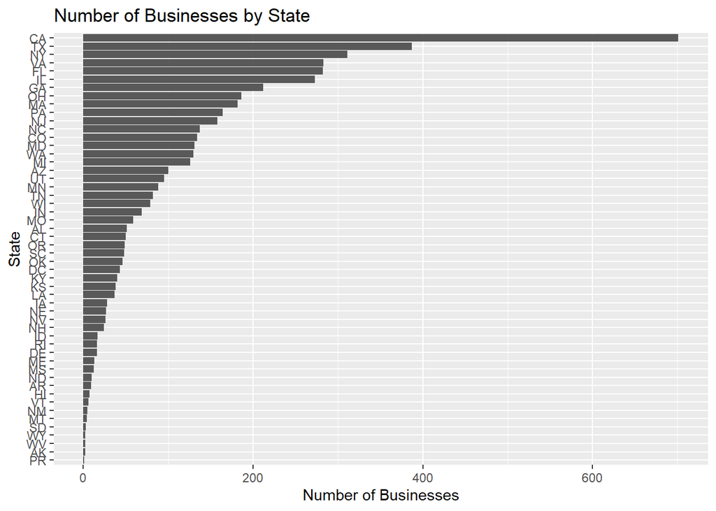

```r
library(ggplot2)
ggplot(inc, aes(x = reorder(inc$State,inc$State,length))) +
  geom_bar() +
  coord_flip() +
  ggtitle("Number of Businesses by State") +
  xlab('State')  +
  ylab('Number of Businesses')
```

## Quesiton 2

Lets dig in on the state with the 3rd most companies in the data set. Imagine you work for the state and are interested in how many people are employed by companies in different industries. Create a plot that shows the average and/or median employment by industry for companies in this state (only use cases with full data, use R’s `complete.cases()` function.) In addition to this, your graph should show how variable the ranges are, and you should deal with outliers.

```r
ny = inc[inc$State=="NY", ]
print(paste(nrow(ny), 'records in NY'))
```

```
## [1] "311 records in NY"
```

```r
ny = ny[complete.cases(ny), ]
print(paste(nrow(ny),'complete records in NY'))
```

```
## [1] "311 complete records in NY"
```

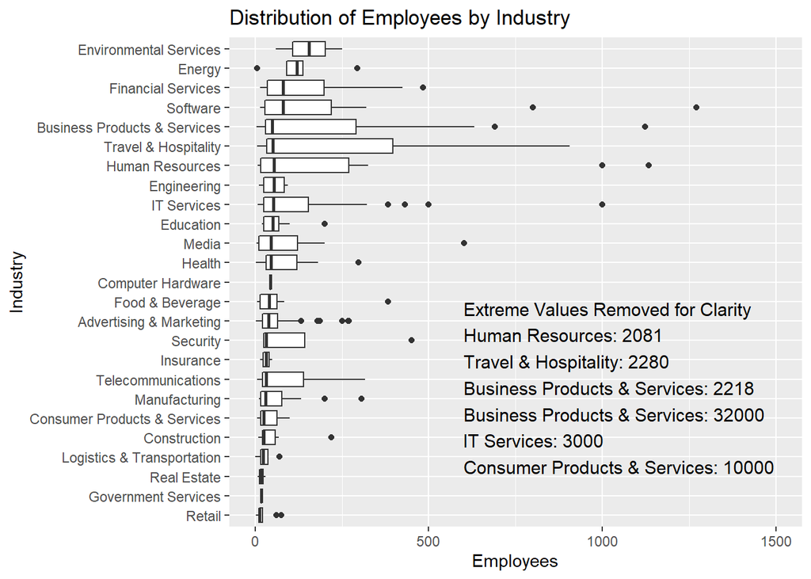

```r
y_lim = 1500

# remove some extreme values but label on the chart, so we could see the distributions better.
caption = 'Extreme Values Removed for Clarity'
outliers = ny[ny['Employees']>y_lim, c('Industry','Employees') ]
for (i in 1:nrow(outliers)){
   caption = paste0(caption,"\n",outliers[i,1],': ',outliers[i,2])
}

ggplot(ny, aes(x = reorder(Industry,Employees,median), y = Employees)) +
  geom_boxplot() +
  coord_flip() +
  ylim(0,y_lim) +
  ggtitle("Distribution of Employees by Industry") +
  xlab('Industry')  +
  ylab('Employees') +
  annotate(
      geom = "text", x = 12, y = 600,
      label = caption, hjust = 0, vjust = 1, size = 4
  )
```

## Question 3

Now imagine you work for an investor and want to see which industries generate the most revenue per employee. Create a chart that makes this information clear. Once again, the distribution per industry should be shown.

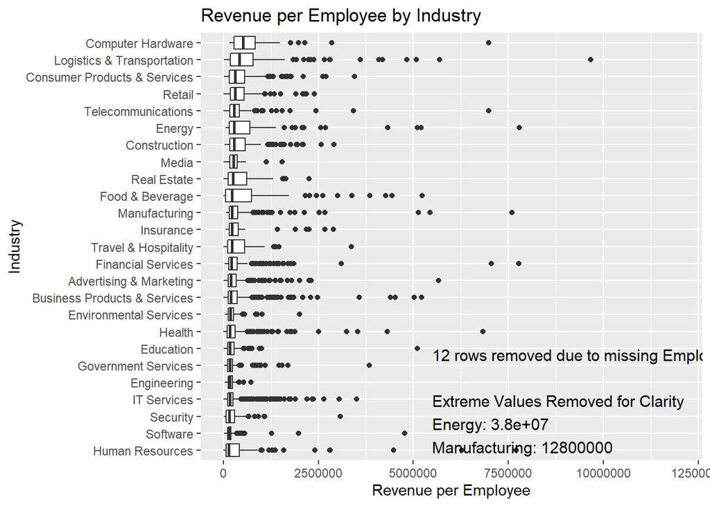

```r
y_lim = 12000000
inc[['rpe']] = inc$Revenue/inc$Employees

inc2 = inc[!is.na(inc$Employees),]
missing_values = nrow(inc)-nrow(inc2)
caption = paste0(missing_values," rows removed due to missing Employees Value\n\n")


# remove some extreme values but label on the chart, so we could see the distributions better.
caption = paste0(caption,'Extreme Values Removed for Clarity')
outliers = inc2[inc2['rpe']>y_lim, c('Industry','rpe') ]
for (i in 1:nrow(outliers)){
   caption = paste0(caption,"\n",outliers[i,1],': ',outliers[i,2])
}

ggplot(inc2, aes(x = reorder(Industry,rpe,median), y = rpe)) +
  geom_boxplot() +
  coord_flip() +
  ylim(0,y_lim) +
  ggtitle("Revenue per Employee by Industry") +
  xlab('Industry')  +
  ylab('Revenue per Employee') +
  annotate(
      geom = "text", x = 7, y = 5500000,
      label = caption, hjust = 0, vjust = 1, size = 4
  )
```